# BMS31004 Bioinformatics for Biomedical Science - Week 5

Module Coordinator Mark Dunning

```r
de_treated <- readRDS("Robjects/de_treated.rds")
dds <- readRDS("Robjects/dds.rds")
```

# Exercise

- Re-run the `DESeq` function to find differentially-expressed genes between the `TGF` treated samples and `CTRL`. You will need to change the `design` that is used.
- Write a csv file that contains results for the genes that have a p-value less than 0.05 and a log2 fold change more than 1, or less than -1.
  - HINT: So that we don’t overwrite our results so far, it may be convenient to create a new `DESeqDataSet` object for the new differential expression analysis. Check the `colData` to see which analyses can be made
- Use the `plotCounts` function to visually-inspect the most statistically-significant gene identified

To change the biological groups that we compare we need to change the `design` component of the dataset. To avoid confusion we can create another object. The same `DESeq` function can be used, except it will analyse a different contrast.

```r
dds_condition<- dds
## make sure that the condition is upper-case and is a factor
dds_condition$condition <- as.factor(stringr::str_to_upper(dds_condition$condition))
dds_condition
```

```
class: DESeqDataSet
dim: 57914 9
metadata(1): version
assays(2): counts avgTxLength
rownames(57914): ENSG00000000003 ENSG00000000005 ...
  ENSG00000284747 ENSG00000284748
rowData names(0):
colnames(9): 1_CTR_BC_2 2_TGF_BC_4 ... 8_TGF_BC_14 9_IR_BC_15
colData names(5): Run condition Name Replicate Treated
```

```r
design(dds_condition) <- ~condition
de_condition <- DESeq(dds_condition)
```

```
using 'avgTxLength' from assays(dds), correcting for library size
```

Conveniently it will compare `TGF` to `CTR` as requested in the exercise

```r
results(de_condition)
```

```
log2 fold change (MLE): condition TGF vs CTR
Wald test p-value: condition TGF vs CTR
DataFrame with 57914 rows and 6 columns
                   baseMean log2FoldChange     lfcSE       stat    pvalue
                  <numeric>      <numeric> <numeric>  <numeric> <numeric>
ENSG00000000003 1447.265802      -0.233372  0.124128 -1.8800995 0.0600945
ENSG00000000005    0.113575      -0.104328  4.080456 -0.0255678 0.9796020
ENSG00000000419 1814.108471      -0.147784  0.142725 -1.0354479 0.3004598
ENSG00000000457  645.735472      -0.204533  0.131904 -1.5506201 0.1209927
ENSG00000000460  221.065743       0.064595  0.262747  0.2458452 0.8058021
...                     ...            ...       ...        ...       ...
ENSG00000284744    8.377622      -0.217574  0.826403  -0.263278  0.792336
ENSG00000284745    0.000000             NA        NA         NA        NA
ENSG00000284746    0.102422      -1.066085  4.080456  -0.261266  0.793887
ENSG00000284747   29.068925      -0.294968  0.476711  -0.618757  0.536077
ENSG00000284748    0.548454       0.857795  4.080456   0.210220  0.833496
                     padj
                <numeric>
ENSG00000000003  0.235475
ENSG00000000005        NA
ENSG00000000419  0.593524
ENSG00000000457  0.356656
ENSG00000000460  0.928951
...                   ...
ENSG00000284744        NA
ENSG00000284745        NA
ENSG00000284746        NA
ENSG00000284747  0.779801
ENSG00000284748        NA
```

```r
results(de_condition,tidy = TRUE) %>%
  arrange(padj) %>%
  filter(padj < 0.05, abs(log2FoldChange) > 1) %>%
  write_csv("DESeq_TGF_vs_CTR.csv")
```

```
using 'avgTxLength' from assays(dds), correcting for library size
```

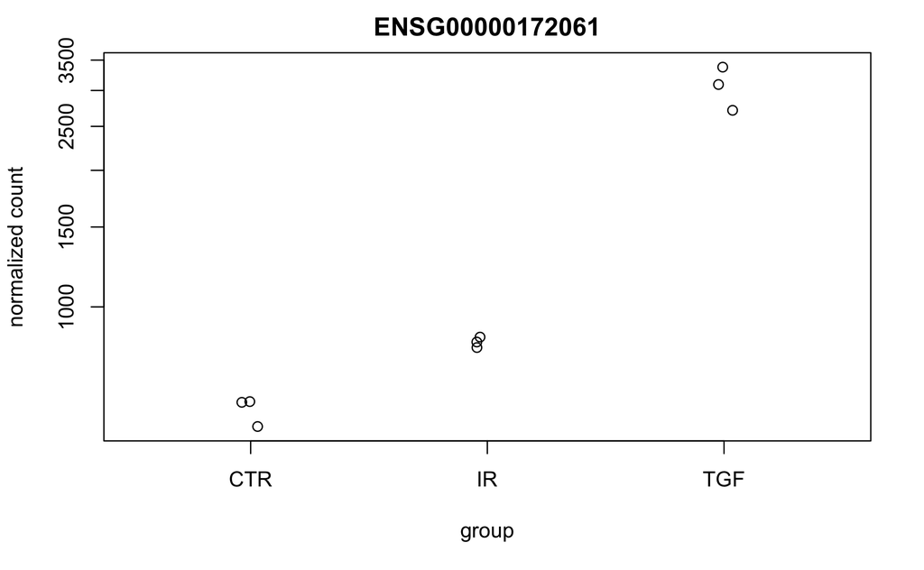

```r
plotCounts(dds_condition, "ENSG00000172061",intgroup = "condition")
```

Setup the annotation ready for the next exercise

```r
library(org.Hs.eg.db)
```

```r
## Get the names of all genes used in the analysis
all_ids <- rownames(dds)
anno <- AnnotationDbi::select(org.Hs.eg.db,keys=all_ids,
            columns=c("ENSEMBL","SYMBOL","GENENAME","ENTREZID"),
            keytype="ENSEMBL") %>%
filter(!duplicated(ENSEMBL))
```

# Exercise

- Join the annotation table to your results from the DESeq analysis of `TGF` vs `CTR`. Save the resulting data frame as a csv file. e.g. `out_data/DESeq_TGF_vs_CTR_annotated.csv`
- The publication gives examples of `COL1A1`, `COL1A2` and `COL3A1` as genes that are *up-regulated* in TGF-treated samples vs controls (Figure 6C). Use your data to verify this by
  - 1. plotting the counts for these genes
  - 2. extracting their p-values

```r
results_condition <- results(de_condition, tidy=TRUE) %>%
  arrange(padj)
results_condition_annotated <- left_join(results_condition, anno,by=c("row"="ENSEMBL"))
write_csv(results_condition_annotated, "out_data/DESeq_TGF_vs_CTR_annotated.csv")
```

Now that the gene names are included in the results we can search for particular genes of interest

```r
filter(results_condition_annotated, SYMBOL %in% c("COL1A1", "COL1A2","COL3A1"))
```

| row | baseMean | log2FoldChange | lfcSE | stat | pvalue | padj | SYMBOL | GENENAME | ENTREZID |
| --- | --- | --- | --- | --- | --- | --- | --- | --- | --- |
| ENSG00000108821 | 333761.14 | 1.3239557 | 0.16216484 | 8.164259 | 3.234151e-16 | 4.266692e-14 | COL1A1 | collagen type I alpha 1 chain | 1277 |
| ENSG00000164692 | 425999.88 | 0.2830741 | 0.06744907 | 4.196857 | 2.706448e-05 | 5.949739e-04 | COL1A2 | collagen type I alpha 2 chain | 1278 |
| ENSG00000168542 | 90234.19 | 0.7384562 | 0.20888666 | 3.535200 | 4.074662e-04 | 5.866135e-03 | COL3A1 | collagen type III alpha 1 chain | 1281 |

Unfortunately `plotCounts` only plots one gene at a time, so we will have to repeat the plot for different genes

```
using 'avgTxLength' from assays(dds), correcting for library size
```

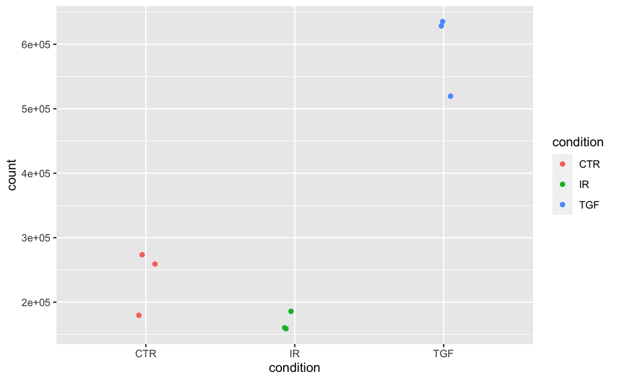

```r
plotCounts(dds_condition, "ENSG00000108821",intgroup = "condition",returnData = TRUE) %>%
  ggplot(aes(x = condition, y = count,col=condition)) + geom_jitter(width=0.1)
```

```
using 'avgTxLength' from assays(dds), correcting for library size
```

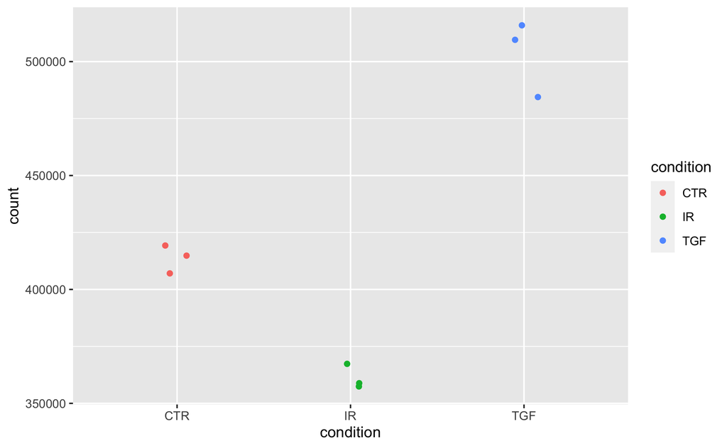

```r
plotCounts(dds_condition, "ENSG00000164692",intgroup = "condition",returnData = TRUE) %>%
  ggplot(aes(x = condition, y = count,col=condition)) + geom_jitter(width=0.1)
```

```
using 'avgTxLength' from assays(dds), correcting for library size
```

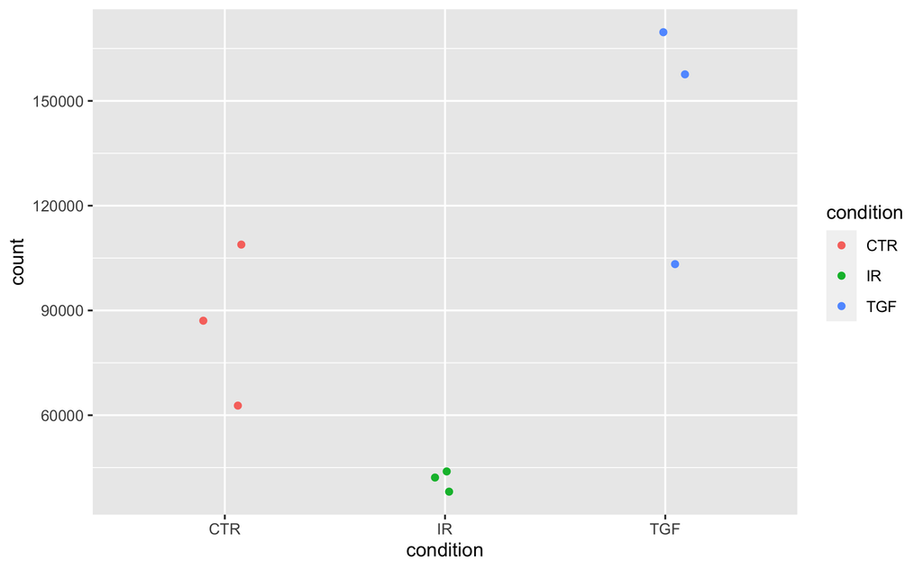

```r
plotCounts(dds_condition, "ENSG00000168542",intgroup = "condition",returnData = TRUE) %>%
  ggplot(aes(x = condition, y = count,col=condition)) + geom_jitter(width=0.1)
```